# Project proposal: Classifying drivers of deforestation in Indonesia

AI for Nature and Environment, individual coding project

Author

Joran van Hemmen

Published

November 6, 2026

## Task and motivation

In this project I will classify the direct driver of a forest-loss event from a satellite image, by predicting the label that is associated with the given satellite image. This matters for nature/environment because if the cause of the forest loss can be detected through one image, the government or the responsible parties can be held accountable quicker. Also actions to prevent forest loss can be implemented quicker. The dataset has satellite images from Indonesia. Indonesia has one of the highest deforestation rates in the world.

## Data

The dataset I intend to use for this project is ForestNet (Irvin et al., 2020). This dataset, ForestNet, is a collection of 2,757 deforestation events in Indonesia. For each one it gives a satellite image of the area and an expert’s label saying what the forest was cleared for. The events are patches of lost forest. Each event comes as an outline of the cleared area plus the year it happened. An expert interpreter then labelled the direct driver. The data is divided into 4 classes: Plantation, Smallholder agriculture, Grassland/shrubland, and Other. The classes are imbalanced, for example the grassland is only 10% of the dataset.

The data is split 1616/473/668 (2757). Images in different splits don’t overlap spatially, so the test set measures how well the model works on new areas, not on neighboring pixels it has seen before. The validation and test labels were also checked by hand and corrected where needed, so they’re cleaner than the training labels.

```python
from pathlib import Path

import matplotlib.pyplot as plt
import numpy as np
import pandas as pd
from PIL import Image

DATA_DIR = Path("deep/downloads/ForestNetDataset")  # folder created by unzipping ForestNetDataset.zip

if not DATA_DIR.exists():
    raise FileNotFoundError(
        f"{DATA_DIR.resolve()} not found. Unzip ForestNetDataset.zip there or edit DATA_DIR."
    )

# Load the official train / val / test splits
splits = {}
for name in ["train", "val", "test"]:
    csv = next(DATA_DIR.rglob(f"{name}.csv"))
    splits[name] = pd.read_csv(csv).assign(split=name)
df = pd.concat(splits.values(), ignore_index=True)

# 4-class label column ('merged_label' in ForestNet; fall back to 'label')
LABEL = "merged_label" if "merged_label" in df.columns else "label"
CSV_ROOT = csv.parent


def example_dir(path_str):
    """Resolve an example folder from the CSV's example_path column."""
    for cand in (CSV_ROOT / path_str, CSV_ROOT / "examples" / path_str, DATA_DIR / path_str):
        if cand.exists():
            return cand
    raise FileNotFoundError(path_str)


def visible_image(ex_dir):
    """Return the composite RGB image of one example (or the first visible PNG)."""
    vis = ex_dir / "images" / "visible"
    comp = vis / "composite.png"
    return Image.open(comp if comp.exists() else sorted(vis.glob("*.png"))[0])


print(f"Columns: {list(df.columns)}")
print(f"Examples loaded: {len(df)}")

counts = pd.crosstab(df[LABEL], df["split"], margins=True, margins_name="total")
counts[["train", "val", "test", "total"]]
```

```
Columns: ['label', 'merged_label', 'latitude', 'longitude', 'year', 'example_path', 'split']
Examples loaded: 2757
```

| split merged_label | train | val | test | total |
| --- | --- | --- | --- | --- |
| Grassland shrubland | 143 | 45 | 77 | 265 |
| Other | 231 | 70 | 106 | 407 |
| Plantation | 686 | 218 | 269 | 1173 |
| Smallholder agriculture | 556 | 140 | 216 | 912 |
| total | 1616 | 473 | 668 | 2757 |

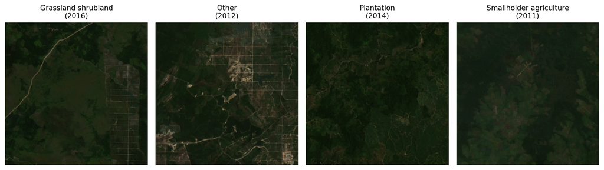

Figure 1: One training example per driver class (Landsat 8 composite, visible bands).

```
Infrared array shape for one example: (332, 332, 3)
```

```python
classes = sorted(df[LABEL].unique())
train = df[df["split"] == "train"]

fig, axes = plt.subplots(1, len(classes), figsize=(3 * len(classes), 3.3))
for ax, cls in zip(np.atleast_1d(axes), classes):
    row = train[train[LABEL] == cls].iloc[0]
    img = visible_image(example_dir(row["example_path"]))
    ax.imshow(img)
    ax.set_title(f"{cls}\n({row['year']})" if "year" in row else cls, fontsize=10)
    ax.axis("off")
plt.tight_layout()
plt.show()

# Which extra bands are available? (useful for the RGB vs. all-bands comparison)
ex = example_dir(train.iloc[0]["example_path"])
ir = sorted((ex / "images" / "infrared").glob("*.npy"))
if ir:
    print(f"Infrared array shape for one example: {np.load(ir[0]).shape}")
else:
    print("No infrared .npy files found for this example.")
```

## Data processing

I will use one cloud-reduced composite per event, so each event counts once. The four merged classes will become integer labels, and I will keep the official spatial split. Images will be centre-cropped to 160×160 px (≈2.4 km) around the loss region, excluding surrounding land use. I will scale pixel values and standardise each band using training-set statistics (ImageNet statistics for the pretrained RGB CNN). I will augment training images with flips and 90° rotations, since overhead imagery has no natural orientation. The loss will be weighted inversely to class frequency (grassland/shrubland ≈10%), with matching class weights in the random forest.

## Methods

A random forest is going to be used as a baseline on the summary features. The main model that will be used is an ImageNet-pretrained CNN (ResNet-18). With only 1,616 training images, a ResNet-18 trained from scratch would overfit. ImageNet-pretrained features such as edges, textures and shapes transfer well to satellite imagery, so fine-tuning only needs to adapt the later layers. The classes differ mainly in spatial pattern, like plantation rows or irregular smallholder plots. In ForestNet, a CNN reached 0.70 macro-F1 against 0.44 for a random forest. I keep the random forest as a baseline to measure what spatial pattern adds.

## Evaluation

My main metric will be macro-F1, which weights the small grassland/shrubland class equally with plantation. Always predicting “plantation” gives 40% accuracy but only 0.14 macro-F1, which will be my majority-class baseline. I will also report per-class F1 and a confusion matrix. Using the official spatial split, I will tune on validation and test once. Then I will analyse grassland–smallholder confusions and use Grad-CAM to check whether the model focuses on the cleared area.

## Weekly milestones

| Dates | Milestone |
| --- | --- |
| 6 to 8 Nov | Dataset downloaded and opened; proposal rendered and submitted |
| 9 to 13 Nov | Preprocessing pipeline; random-forest baseline with macro-F1 and confusion matrix |
| 16 to 20 Nov | Fine-tuned CNN on Colab; Grad-CAM and error analysis |
| 23 to 25 Nov | Report written (introduction, method, results, discussion, AI statement) |
| 26 Nov | 7-minute presentation recorded; final render; zip prepared |
| 27 Nov | Buffer for unexpected issues; final submission |

## AI usage statement

I used Claude to help me understand the dataset and the project. I used Claude Code to render me a qmd template.

## References

Irvin, J., Sheng, H., Ramachandran, N., Johnson-Yu, S., Zhou, S., Story, K., Rustowicz, R., Elsworth, C., Austin, K., & Ng, A. Y. (2020). ForestNet: Classifying drivers of deforestation in Indonesia using deep learning on satellite imagery. *NeurIPS 2020 Workshop on Tackling Climate Change with Machine Learning*. https://arxiv.org/abs/2011.05479

Dataset: https://stanfordmlgroup.github.io/projects/forestnet